# Cleaning & Exploring Data

###Downloading the data

```r
setwd("C:\\Users\\hang\\Desktop\\Coursera_5Top\\PracticalMachineLearning\\Project\\")
```

```
## Error: cannot change working directory
```

```r
if(!file.exists("data")){
    dir.create("data")
}
###downloading "training" data
fileURL<-"http://d396qusza40orc.cloudfront.net/predmachlearn/pml-training.csv" ## replace "https" to "http" then worked!
download.file(fileURL, destfile="./data/training.csv")
dateDownloaded<-date()
dateDownloaded
```

```
## [1] "Sun Sep 21 00:03:56 2014"
```

```r
###downloading "testing" data
fileURL<-"http://d396qusza40orc.cloudfront.net/predmachlearn/pml-testing.csv" ## replace "https" to "http" then worked!
download.file(fileURL, destfile="./data/testing.csv")
dateDownloaded<-date()
dateDownloaded
```

```
## [1] "Sun Sep 21 00:03:56 2014"
```

###Loading the “training” and “testing” data.

```r
# The "training" data which is named as "d".
d<-read.csv("./data/training.csv", header=TRUE)
dim(d)
```

```
## [1] 19622   160
```

```r
str(d) # 19622 obs. of 160 vars
```

```
## 'data.frame':    19622 obs. of  160 variables:
##  $ X                       : int  1 2 3 4 5 6 7 8 9 10 ...
##  $ user_name               : Factor w/ 6 levels "adelmo","carlitos",..: 2 2 2 2 2 2 2 2 2 2 ...
##  $ raw_timestamp_part_1    : int  1323084231 1323084231 1323084231 1323084232 1323084232 1323084232 1323084232 1323084232 1323084232 1323084232 ...
##  $ raw_timestamp_part_2    : int  788290 808298 820366 120339 196328 304277 368296 440390 484323 484434 ...
##  $ cvtd_timestamp          : Factor w/ 20 levels "02/12/2011 13:32",..: 9 9 9 9 9 9 9 9 9 9 ...
##  $ new_window              : Factor w/ 2 levels "no","yes": 1 1 1 1 1 1 1 1 1 1 ...
##  $ num_window              : int  11 11 11 12 12 12 12 12 12 12 ...
##  $ roll_belt               : num  1.41 1.41 1.42 1.48 1.48 1.45 1.42 1.42 1.43 1.45 ...
##  $ pitch_belt              : num  8.07 8.07 8.07 8.05 8.07 8.06 8.09 8.13 8.16 8.17 ...
##  $ yaw_belt                : num  -94.4 -94.4 -94.4 -94.4 -94.4 -94.4 -94.4 -94.4 -94.4 -94.4 ...
##  $ total_accel_belt        : int  3 3 3 3 3 3 3 3 3 3 ...
##  $ kurtosis_roll_belt      : Factor w/ 397 levels "","-0.016850",..: 1 1 1 1 1 1 1 1 1 1 ...
##  $ kurtosis_picth_belt     : Factor w/ 317 levels "","-0.021887",..: 1 1 1 1 1 1 1 1 1 1 ...
##  $ kurtosis_yaw_belt       : Factor w/ 2 levels "","#DIV/0!": 1 1 1 1 1 1 1 1 1 1 ...
```

[output cut: 86 more lines]

```r
summary(d) # the last var "classe" is outcome to be predicted.
```

```
##        X            user_name    raw_timestamp_part_1 raw_timestamp_part_2
##  Min.   :    1   adelmo  :3892   Min.   :1.32e+09     Min.   :   294
##  1st Qu.: 4906   carlitos:3112   1st Qu.:1.32e+09     1st Qu.:252912
##  Median : 9812   charles :3536   Median :1.32e+09     Median :496380
##  Mean   : 9812   eurico  :3070   Mean   :1.32e+09     Mean   :500656
##  3rd Qu.:14717   jeremy  :3402   3rd Qu.:1.32e+09     3rd Qu.:751891
##  Max.   :19622   pedro   :2610   Max.   :1.32e+09     Max.   :998801
##
##           cvtd_timestamp  new_window    num_window    roll_belt
##  28/11/2011 14:14: 1498   no :19216   Min.   :  1   Min.   :-28.9
##  05/12/2011 11:24: 1497   yes:  406   1st Qu.:222   1st Qu.:  1.1
##  30/11/2011 17:11: 1440               Median :424   Median :113.0
##  05/12/2011 11:25: 1425               Mean   :431   Mean   : 64.4
##  02/12/2011 14:57: 1380               3rd Qu.:644   3rd Qu.:123.0
##  02/12/2011 13:34: 1375               Max.   :864   Max.   :162.0
##  (Other)         :11007
##    pitch_belt        yaw_belt      total_accel_belt kurtosis_roll_belt
##  Min.   :-55.80   Min.   :-180.0   Min.   : 0.0              :19216
##  1st Qu.:  1.76   1st Qu.: -88.3   1st Qu.: 3.0     #DIV/0!  :   10
##  Median :  5.28   Median : -13.0   Median :17.0     -1.908453:    2
##  Mean   :  0.31   Mean   : -11.2   Mean   :11.3     -0.016850:    1
##  3rd Qu.: 14.90   3rd Qu.:  12.9   3rd Qu.:18.0     -0.021024:    1
##  Max.   : 60.30   Max.   : 179.0   Max.   :29.0     -0.025513:    1
##                                                     (Other)  :  391
##  kurtosis_picth_belt kurtosis_yaw_belt skewness_roll_belt
##           :19216            :19216              :19216
##  #DIV/0!  :   32     #DIV/0!:  406     #DIV/0!  :    9
##  47.000000:    4                       0.000000 :    4
##  -0.150950:    3                       0.422463 :    2
##  -0.684748:    3                       -0.003095:    1
##  -1.750749:    3                       -0.010002:    1
##  (Other)  :  361                       (Other)  :  389
##  skewness_roll_belt.1 skewness_yaw_belt max_roll_belt   max_picth_belt
##           :19216             :19216     Min.   :-94     Min.   : 3
##  #DIV/0!  :   32      #DIV/0!:  406     1st Qu.:-88     1st Qu.: 5
##  0.000000 :    4                        Median : -5     Median :18
##  -2.156553:    3                        Mean   : -7     Mean   :13
##  -3.072669:    3                        3rd Qu.: 18     3rd Qu.:19
##  -6.324555:    3                        Max.   :180     Max.   :30
##  (Other)  :  361                        NA's   :19216   NA's   :19216
```

[output cut: 289 more lines]

```
##  Min.   : -8.09   Min.   :-498.0   Min.   :-632    Min.   :-446.0
##  1st Qu.: -0.18   1st Qu.:-178.0   1st Qu.:  57    1st Qu.:-182.0
##  Median :  0.08   Median : -57.0   Median : 201    Median : -39.0
##  Mean   :  0.15   Mean   : -61.7   Mean   : 164    Mean   : -55.3
##  3rd Qu.:  0.49   3rd Qu.:  76.0   3rd Qu.: 312    3rd Qu.:  26.0
##  Max.   :231.00   Max.   : 477.0   Max.   : 923    Max.   : 291.0
##
##  magnet_forearm_x magnet_forearm_y magnet_forearm_z classe
##  Min.   :-1280    Min.   :-896     Min.   :-973     A:5580
##  1st Qu.: -616    1st Qu.:   2     1st Qu.: 191     B:3797
##  Median : -378    Median : 591     Median : 511     C:3422
##  Mean   : -313    Mean   : 380     Mean   : 394     D:3216
##  3rd Qu.:  -73    3rd Qu.: 737     3rd Qu.: 653     E:3607
##  Max.   :  672    Max.   :1480     Max.   :1090
##
```

```r
# The "testing" data which is named as "d2".
d2<-read.csv("./data/testing.csv", header=TRUE)
dim(d2)
```

```
## [1]  20 160
```

```r
str(d2) # 20 obs. of 160 vars
```

```
## 'data.frame':    20 obs. of  160 variables:
##  $ X                       : int  1 2 3 4 5 6 7 8 9 10 ...
##  $ user_name               : Factor w/ 6 levels "adelmo","carlitos",..: 6 5 5 1 4 5 5 5 2 3 ...
##  $ raw_timestamp_part_1    : int  1323095002 1322673067 1322673075 1322832789 1322489635 1322673149 1322673128 1322673076 1323084240 1322837822 ...
##  $ raw_timestamp_part_2    : int  868349 778725 342967 560311 814776 510661 766645 54671 916313 384285 ...
##  $ cvtd_timestamp          : Factor w/ 11 levels "02/12/2011 13:33",..: 5 10 10 1 6 11 11 10 3 2 ...
##  $ new_window              : Factor w/ 1 level "no": 1 1 1 1 1 1 1 1 1 1 ...
##  $ num_window              : int  74 431 439 194 235 504 485 440 323 664 ...
##  $ roll_belt               : num  123 1.02 0.87 125 1.35 -5.92 1.2 0.43 0.93 114 ...
##  $ pitch_belt              : num  27 4.87 1.82 -41.6 3.33 1.59 4.44 4.15 6.72 22.4 ...
##  $ yaw_belt                : num  -4.75 -88.9 -88.5 162 -88.6 -87.7 -87.3 -88.5 -93.7 -13.1 ...
##  $ total_accel_belt        : int  20 4 5 17 3 4 4 4 4 18 ...
##  $ kurtosis_roll_belt      : logi  NA NA NA NA NA NA ...
##  $ kurtosis_picth_belt     : logi  NA NA NA NA NA NA ...
##  $ kurtosis_yaw_belt       : logi  NA NA NA NA NA NA ...
```

[output cut: 86 more lines]

```r
summary(d2) # the last var "classe" is outcome to be predicted.
```

```
##        X            user_name raw_timestamp_part_1 raw_timestamp_part_2
##  Min.   : 1.00   adelmo  :1   Min.   :1.32e+09     Min.   : 36553
##  1st Qu.: 5.75   carlitos:3   1st Qu.:1.32e+09     1st Qu.:268655
##  Median :10.50   charles :1   Median :1.32e+09     Median :530706
##  Mean   :10.50   eurico  :4   Mean   :1.32e+09     Mean   :512167
##  3rd Qu.:15.25   jeremy  :8   3rd Qu.:1.32e+09     3rd Qu.:787738
##  Max.   :20.00   pedro   :3   Max.   :1.32e+09     Max.   :920315
##
##           cvtd_timestamp new_window   num_window    roll_belt
##  30/11/2011 17:11:4      no:20      Min.   : 48   Min.   : -5.92
##  05/12/2011 11:24:3                 1st Qu.:250   1st Qu.:  0.91
##  30/11/2011 17:12:3                 Median :384   Median :  1.11
##  05/12/2011 14:23:2                 Mean   :380   Mean   : 31.31
##  28/11/2011 14:14:2                 3rd Qu.:467   3rd Qu.: 32.51
##  02/12/2011 13:33:1                 Max.   :859   Max.   :129.00
##  (Other)         :5
##    pitch_belt        yaw_belt     total_accel_belt kurtosis_roll_belt
##  Min.   :-41.60   Min.   :-93.7   Min.   : 2.00    Mode:logical
##  1st Qu.:  3.01   1st Qu.:-88.6   1st Qu.: 3.00    NA's:20
##  Median :  4.66   Median :-87.8   Median : 4.00
##  Mean   :  5.82   Mean   :-59.3   Mean   : 7.55
##  3rd Qu.:  6.13   3rd Qu.:-63.5   3rd Qu.: 8.00
##  Max.   : 27.80   Max.   :162.0   Max.   :21.00
##
##  kurtosis_picth_belt kurtosis_yaw_belt skewness_roll_belt
##  Mode:logical        Mode:logical      Mode:logical
##  NA's:20             NA's:20           NA's:20
##
##
##
##
##
##  skewness_roll_belt.1 skewness_yaw_belt max_roll_belt  max_picth_belt
##  Mode:logical         Mode:logical      Mode:logical   Mode:logical
##  NA's:20              NA's:20           NA's:20        NA's:20
##
##
##
##
##
```

[output cut: 289 more lines]

```
##  Min.   :-1.2600   Min.   :-212.0   Min.   :-331.0   Min.   :-282.0
##  1st Qu.:-0.0975   1st Qu.:-114.8   1st Qu.:   8.5   1st Qu.:-199.0
##  Median : 0.2300   Median :  86.0   Median : 138.0   Median :-148.5
##  Mean   : 0.2610   Mean   :  38.8   Mean   : 125.3   Mean   : -93.7
##  3rd Qu.: 0.7625   3rd Qu.: 166.2   3rd Qu.: 268.0   3rd Qu.: -31.0
##  Max.   : 1.8000   Max.   : 232.0   Max.   : 406.0   Max.   : 179.0
##
##  magnet_forearm_x magnet_forearm_y magnet_forearm_z   problem_id
##  Min.   :-714.0   Min.   :-787     Min.   :-32      Min.   : 1.00
##  1st Qu.:-427.2   1st Qu.:-329     1st Qu.:275      1st Qu.: 5.75
##  Median :-189.5   Median : 487     Median :492      Median :10.50
##  Mean   :-159.2   Mean   : 192     Mean   :460      Mean   :10.50
##  3rd Qu.:  41.5   3rd Qu.: 721     3rd Qu.:662      3rd Qu.:15.25
##  Max.   : 532.0   Max.   : 800     Max.   :884      Max.   :20.00
##
```

### Cleaning & Exploring Data

I noticed that there are many variables that contain a large number of NAs, several variables have value “DIV/0!”. To review the data in details, I used Hmisc package and options() function.

```r
# NA details
library(Hmisc)
options(na.action="na.keep", na.detail.response=TRUE)
# review the dataframe "d".
a<-describe(d)
a[1:20]
```

```
## d
##
##  20  Variables      19622  Observations
## ---------------------------------------------------------------------------
## X
##       n missing  unique    Mean     .05     .10     .25     .50     .75
##   19622       0   19622    9812   982.1  1963.1  4906.2  9811.5 14716.8
##     .90     .95
## 17659.9 18641.0
##
## lowest :     1     2     3     4     5
## highest: 19618 19619 19620 19621 19622
## ---------------------------------------------------------------------------
## user_name
##       n missing  unique
##   19622       0       6
##
##           adelmo carlitos charles eurico jeremy pedro
## Frequency   3892     3112    3536   3070   3402  2610
## %             20       16      18     16     17    13
## ---------------------------------------------------------------------------
## raw_timestamp_part_1
##         n   missing    unique      Mean       .05       .10       .25
##     19622         0       837 1.323e+09 1.322e+09 1.322e+09 1.323e+09
##       .50       .75       .90       .95
## 1.323e+09 1.323e+09 1.323e+09 1.323e+09
##
## lowest : 1322489605 1322489606 1322489607 1322489608 1322489609
## highest: 1323095077 1323095078 1323095079 1323095080 1323095081
## ---------------------------------------------------------------------------
## raw_timestamp_part_2
##       n missing  unique    Mean     .05     .10     .25     .50     .75
##   19622       0   16783  500656   48389  100343  252912  496380  751891
##     .90     .95
##  900367  950649
##
## lowest :    294    301    307    309    312
## highest: 998716 998741 998749 998750 998801
## ---------------------------------------------------------------------------
## cvtd_timestamp
```

[output cut: 102 more lines]

```
## ---------------------------------------------------------------------------
## max_picth_belt
##       n missing  unique    Mean     .05     .10     .25     .50     .75
##     406   19216      22   12.92       3       3       5      18      19
##     .90     .95
##      21      26
##
## lowest :  3  4  5  6  7, highest: 25 26 27 28 30
## ---------------------------------------------------------------------------
## max_yaw_belt
##       n missing  unique
##   19622       0      68
##
## lowest :      -0.1 -0.2 -0.3 -0.4, highest: 5.6  5.7  6.5  7.0  7.5
## ---------------------------------------------------------------------------
```

```r
# can review more contents of a.
```

To remove the variables with a large number of NAs, I first created a function to identify the indices for the variables with NAs. The variables containing NAs, “#DIV/0!” and empty cells should be removed. In addition, the first 6 column variables which are not dirrectly corresponding to the exercise manner would also be removed. Total 54 of variables were remained in the data frame.

```r
d_na.rm<-d
d_na.rm<-d_na.rm[,-c(1:6, 12:16, 17:19, 21, 22, 24, 25, 26, 27, 28:30, 31:36, 50:59,
        69:74, 75:80, 81:83, 87, 90, 92,93, 94, 96, 97, 99, 100, 101, 103:112,
        125, 126, 128, 129, 131, 132, 133,  134, 135, 136, 137, 138, 139,141:150, 89, 127, 130, 20, 23, 88, 91, 95, 98)]
dim(d_na.rm)
```

```
## [1] 19622    54
```

###Splitting the Data

```r
library(caret)
set.seed(33833)
inTrain<-createDataPartition(d_na.rm$classe, p=3/4, list=FALSE)
training<-d_na.rm[inTrain,]
testing<-d_na.rm[-inTrain,]
```

###Plotting Predictors  
I used 'car' package to make scatter plot on outcome variable “classe” with multiple pairs of predictors. Here shows an example, the plot shows relationship of “classe” with a few predictors on “belt” which suggested some potentials for good predictors.

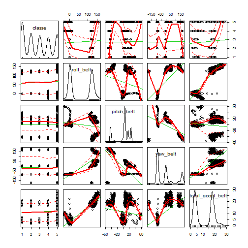

```r
library(car)
scatterplotMatrix(~classe+roll_belt+pitch_belt+yaw_belt+total_accel_belt, span=0.7, data=training)
```

```r
dev.copy(png, file="belt.scatterplot.pairs_1.png")
```

```r
dev.off()
```

###PreProcess using the caret package  
After cleaning the data, there are 54 variables remained. However, some of those variables may be correlated. I used principle componenent analysis to preProcess the data. The results showed that 26 componenets can capture 95% of the variance.

```r
preProc<-preProcess(training[,-54], method="pca") #26 components to capture 95% of the variance.
preProc
```

```
##
## Call:
## preProcess.default(x = training[, -54], method = "pca")
##
## Created from 14718 samples and 53 variables
## Pre-processing: principal component signal extraction, scaled, centered
##
## PCA needed 26 components to capture 95 percent of the variance
```